# CRISP-DM (Cross Industry Standard Process for Data Mining)

### Types of accidents

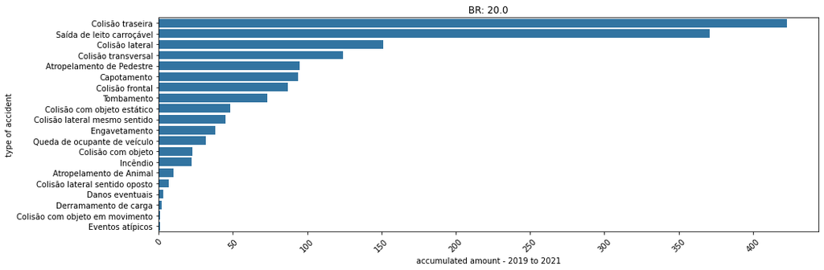

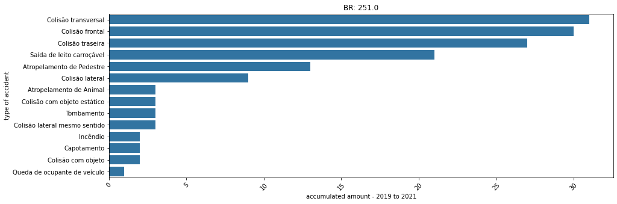

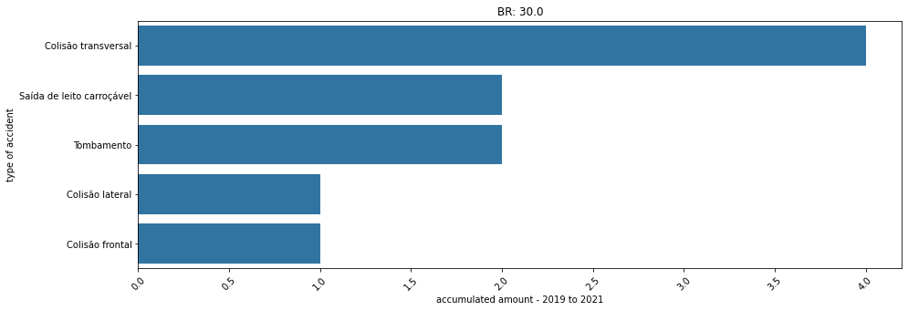

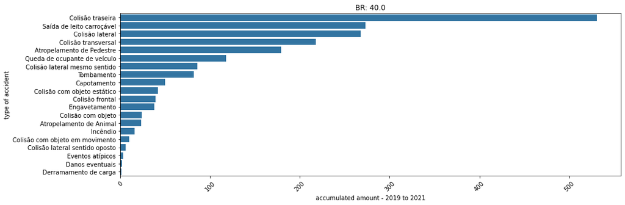

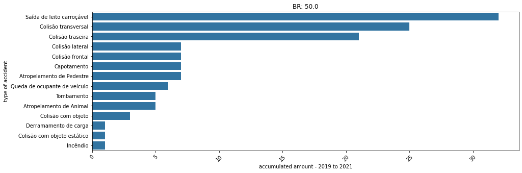

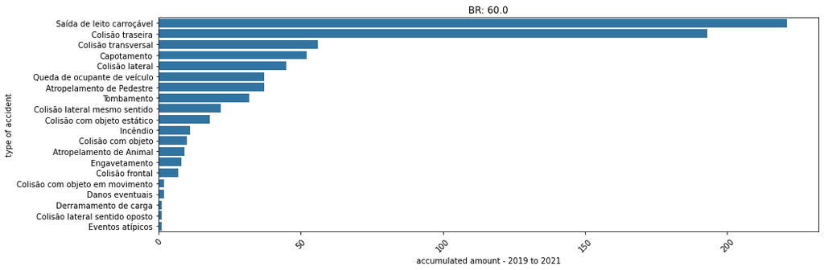

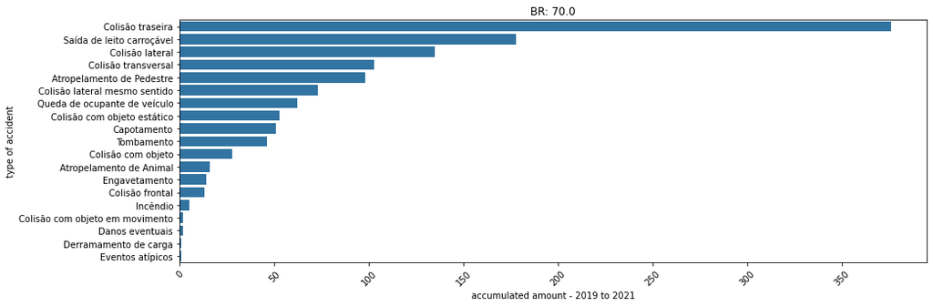

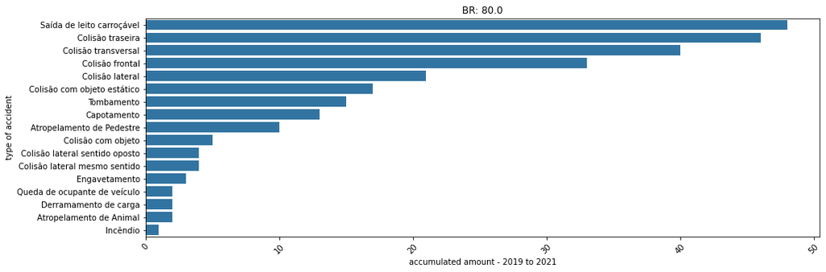

```python
# Types of accidents
lista_br = new_df['br'].value_counts().index.sort_values()
base_color = sb.color_palette()[0]
for br in lista_br:
    acdfoco = new_df[new_df['br'] == br]
    order = acdfoco['tipo_acidente'].value_counts().index
    plt.figure(figsize=(15, 5))
    plot = sb.countplot(data=acdfoco, y='tipo_acidente', order=order, color=base_color)
    plt.xticks(rotation=45)
    plt.title(f'BR: {br}')
    plt.xlabel('accumulated amount - 2019 to 2021')
    plt.ylabel('type of accident')
    plt.show();
```

### Hour

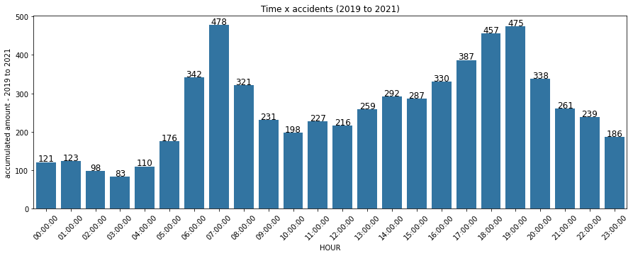

```python
# Times with the highest number of accidents
order = new_df['hour'].value_counts().index.sort_values()
base_color = sb.color_palette()[0]
plt.figure(figsize=(15, 5))
plot = sb.countplot(data=new_df, x='hour', order=order, color=base_color)
plt.xticks(rotation=45)
plt.title(f'Time x accidents (2019 to 2021)')
plt.xlabel('HOUR')
plt.ylabel('accumulated amount - 2019 to 2021')
for i in plot.patches:
    plot.annotate(i.get_height(),
                  (i.get_x() + i.get_width() / 2, i.get_height()),
                  ha='center',
                  va='baseline',
                  fontsize=12,
                  color='black',
                  xytext=(0, 1),
                  textcoords='offset points')
plt.show();
```

### Month

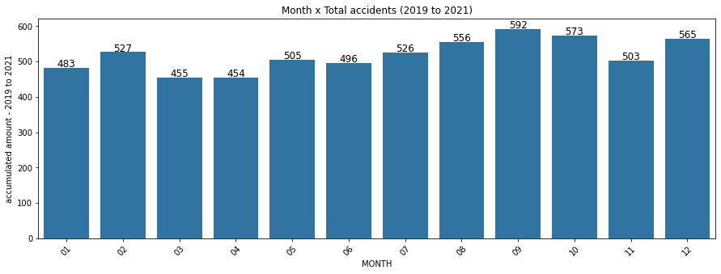

```python
base_color = sb.color_palette()[0]
order = {'01': 'janeiro', '02': 'fevereiro', '03': 'marco', '04': 'abril', '05': 'maio',
             '06': 'junho', '07': 'julho', '08': 'agosto', '09': 'setembro', '10': 'outubro',
             '11': 'novembro', '12': 'dezembro'}
plt.figure(figsize=(15, 5))
plot = sb.countplot(data=new_df, x='mes', order= order, color=base_color)
plt.xticks(rotation=45)
plt.title(f'Month x Total accidents (2019 to 2021)')
plt.xlabel('MONTH')
plt.ylabel('accumulated amount - 2019 to 2021')
for i in plot.patches:
    plot.annotate(i.get_height(),
                  (i.get_x() + i.get_width() / 2, i.get_height()),
                  ha='center',
                  va='baseline',
                  fontsize=12,
                  color='black',
                  xytext=(0, 1),
                  textcoords='offset points')
plt.show();
```

### BR

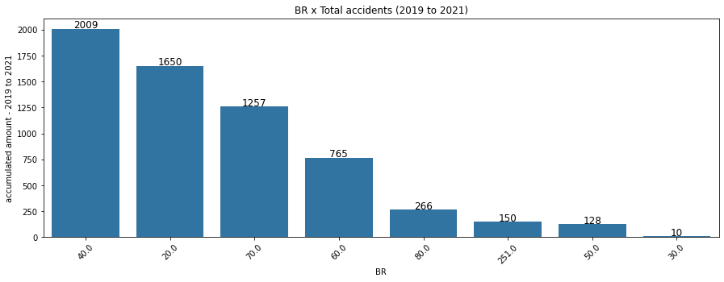

```python
base_color = sb.color_palette()[0]
order = new_df['br'].value_counts().index
plt.figure(figsize=(15, 5))
plot = sb.countplot(data=new_df, x='br', order= order, color=base_color)
plt.xticks(rotation=45)
plt.title(f'BR x Total accidents (2019 to 2021)')
plt.xlabel('BR')
plt.ylabel('accumulated amount - 2019 to 2021')
for i in plot.patches:
    plot.annotate(i.get_height(),
                  (i.get_x() + i.get_width() / 2, i.get_height()),
                  ha='center',
                  va='baseline',
                  fontsize=12,
                  color='black',
                  xytext=(0, 1),
                  textcoords='offset points')
plt.show();
```

### Holiday

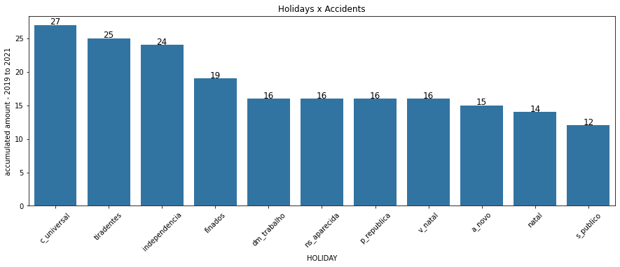

```python
base_color = sb.color_palette()[0]
df_feriado = new_df[new_df['holiday'] != 'normal_day']
order = df_feriado['holiday'].value_counts().index
plt.figure(figsize=(15, 5))
plot = sb.countplot(data=df_feriado, x='holiday', order=order, color=base_color)
for i in plot.patches:
    plot.annotate(f'{i.get_height()}',
                  (i.get_x() + i.get_width() / 2, i.get_height()),
                  ha='center',
                  va='baseline',
                  fontsize=12,
                  color='black',
                  xytext=(0, 1),
                  textcoords='offset points')
plt.xticks(rotation=45)
plt.title(f'Holidays x Accidents')
plt.ylabel('accumulated amount - 2019 to 2021')
plt.xlabel('HOLIDAY')
plt.show();
```

The data are for 2019, 2020 and 2021: https://www.gov.br/prf/pt-br/acesso-a-informacao/dados-abertos/dados-abertos-acidentes

Of the federal highways that pass through the Federal District, four have a significant number of accidents:

- BR 020
- BR 040
- BR 060
- BR 070

Period with the highest number of victims in serious condition and/or deaths:

- Weekend with public holiday

BR and month with the highest number of accidents:

- BR 20 = December > October > September > February
- BR 40 = August > September > July > October
- BR 60 = December > September > June e February
- BR 70 = Showed little oscillation. Keeping an average always high.

The BR 40 had the highest number of accidents. Followed by BR 20 and then BR 70

Most critical point in each BR:

- BR 20 = KM 9
- BR 251 = KM 32
- BR 40 = KM 5
- BR 50 = KM 96
- BR 60 = KM 4
- BR 70 = KM 9
- BR 80 = KM 25.

Most frequent type of accident in each BR:

- BR 20 = Rear collision
- BR 251 = Cross collision
- BR 40 = Rear collision
- BR 50 = Exit from the carousel bed
- BR 60 = Exit from the carousel bed
- BR 70 = Rear collision
- BR 80 = Exit from the carousel bed

The holiday with the most accidents:

- 1st - 'Confraternização Universal'
- 2nd - 'Tiradentes'
- 3rd - 'Independência'
- 4th - 'Finados'
- 5th - 'Trabalho'
- 6th - 'Nossa Senhora Aparecida'
- 7th - 'Proclamação da República'
- 8th - 'Véspera de Natal'
- 9th - 'Ano Novo'
- 10th - 'Natal'
- 11th - 'Servidor Público'

The month with the highest number of accidents is September.

Time with the highest number of accidents:

- 1st - 07:00am
- 2nd - 07:00pm

## 4. Data modeling

```
- Instantiate
- Standardize
- Fit
- Predict
- Score
```

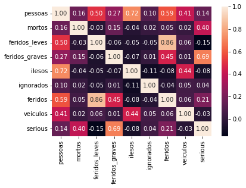

```python
sb.heatmap(new_df.corr(), annot=True, fmt=".2f");
```

```python
new_df.dtypes.sort_values()
```

```
mortos                     int64
feridos_graves             int64
ilesos                     int64
ignorados                  int64
feridos                    int64
veiculos                   int64
feridos_leves              int64
pessoas                    int64
serious                    int64
uop                       object
longitude                 object
latitude                  object
dia                       object
mes                       object
ano                       object
holiday                   object
delegacia                 object
regional                  object
id                        object
uso_solo                  object
data_inversa              object
dia_semana                object
horario                   object
uf                        object
br                        object
km                        object
municipio                 object
causa_acidente            object
tipo_acidente             object
classificacao_acidente    object
fase_dia                  object
sentido_via               object
condicao_metereologica    object
tipo_pista                object
tracado_via               object
week                      object
hour                      object
dtype: object
```

```python
cat_list = ['dia_semana', 'hour', 'br', 'municipio', 'km', 'condicao_metereologica', 'tipo_pista', 'tracado_via', 'uop', 'dia', 'mes', 'week', 'serious']
pd.DataFrame(new_df[cat_list])
data = pd.DataFrame(new_df[cat_list])
```

```python
# Total number of records
n_records = len(data)

# Number of accidents with serious injury or death
serious = (data.groupby(['serious']).size())[1]

# Percentage of individuals whose serious is 1
serious_percent = (serious / len(data)) * 100

print("Total number of records: {}".format(n_records))
print("Accidents with serious injury or death: {}".format(serious))
print("Percentage of accidents with serious injury or death: {:.2f}%".format(serious_percent))
```

```
Total number of records: 6235
Accidents with serious injury or death: 1419
Percentage of accidents with serious injury or death: 22.76%
```

```python
# One-hot encode the 'data' using pandas.get_dummies()
features_final = pd.get_dummies(data, columns=['dia_semana', 'hour', 'br', 'municipio', 'km', 'condicao_metereologica', 'tipo_pista', 'tracado_via', 'uop', 'dia', 'mes', 'week'])
features_final = features_final.drop('serious', axis=1)
income = data['serious']

# Print the number of features after one-hot encoding
encoded = list(features_final.columns)

# Uncomment the following line to see the encoded feature names
print(encoded)
```

```
['dia_semana_domingo', 'dia_semana_quarta-feira', 'dia_semana_quinta-feira', 'dia_semana_segunda-feira', 'dia_semana_sexta-feira', 'dia_semana_sábado', 'dia_semana_terça-feira', 'hour_00:00:00', 'hour_01:00:00', 'hour_02:00:00', 'hour_03:00:00', 'hour_04:00:00', 'hour_05:00:00', 'hour_06:00:00', 'ho…
```

```python
# Split the 'features' and 'income' data into training and testing sets
X_train, X_test, y_train, y_test = train_test_split(features_final, income, test_size=.20, random_state=42)

# Show the results of the split
print("Training set has {} samples.".format(X_train.shape[0]))
print("Testing set has {} samples.".format(X_test.shape[0]))
```

```
Training set has 4988 samples.
Testing set has 1247 samples.
```

```python
TP = np.sum(income) # Counting the ones as this is the naive case. Data encoded to numerical values done in the data preprocessing step.
FP = income.count() - TP # Specific to the naive case

TN = 0 # No predicted negatives in the naive case
FN = 0 # No predicted negatives in the naive case

# Calculate accuracy, precision and recall
accuracy = TP / (TP + FP)
precision = TP / (TP + FP)
recall = TP / (TP + FN)

# Calculate F-score using the formula above for beta = 0.5 and correct values for precision and recall.
beta = 0.5
fscore = (((beta*beta) + 1)) * ((precision*recall) / (((beta*beta)*precision) + recall))

# Print the results
print("Naive Predictor: [Accuracy score: {:.4f}, F-score: {:.4f}]".format(accuracy, fscore))
```

```
Naive Predictor: [Accuracy score: 0.2276, F-score: 0.2692]
```

```python
def train_predict(learner, sample_size, X_train, y_train, X_test, y_test):
    '''
    inputs:
       - learner: the learning algorithm to be trained and predicted on
       - sample_size: the size of samples (number) to be drawn from training set
       - X_train: features training set
       - y_train: income training set
       - X_test: features testing set
       - y_test: income testing set
    '''

    results = {}

    # Fit the learner to the training data using slicing with 'sample_size' using .fit(training_features[:], training_labels[:])
    start = time() # Get start time
    learner = learner.fit(X_train[:sample_size], y_train[:sample_size])
    end = time() # Get end time

    # Calculate the training time
    results['train_time'] = end - start

    # Get the predictions on the test set(X_test),
    #       then get predictions on the first 300 training samples(X_train) using .predict()
    start = time() # Get start time
    predictions_test = learner.predict(X_test)
    predictions_train = learner.predict(X_train[:300])
    end = time() # Get end time

    # Calculate the total prediction time
    results['pred_time'] = end - start

    # Compute accuracy on the first 300 training samples which is y_train[:300]
    results['acc_train'] = accuracy_score(y_train[:300], predictions_train )

    # Compute accuracy on test set using accuracy_score()
    results['acc_test'] = accuracy_score(y_test, predictions_test)

    # Compute F-score on the the first 300 training samples using fbeta_score()
    results['f_train'] = fbeta_score(y_train[:300], predictions_train, beta=0.5)

    # Compute F-score on the test set which is y_test
    results['f_test'] = fbeta_score(y_test, predictions_test, beta=0.5)


    # Success
    print("{} trained on {} samples.".format(learner.__class__.__name__, sample_size))

    # Return the results
    return results
```

```
LogisticRegression trained on 49 samples.
LogisticRegression trained on 498 samples.
```

```
LogisticRegression trained on 4988 samples.
GaussianNB trained on 49 samples.
GaussianNB trained on 498 samples.
GaussianNB trained on 4988 samples.
GradientBoostingClassifier trained on 49 samples.
GradientBoostingClassifier trained on 498 samples.
GradientBoostingClassifier trained on 4988 samples.
```

```
C:\Users\AVELL\Desktop\Data Scientist\Files\prf_data\visuals.py:90: UserWarning: Tight layout not applied. tight_layout cannot make axes width small enough to accommodate all axes decorations
  pl.tight_layout()
```

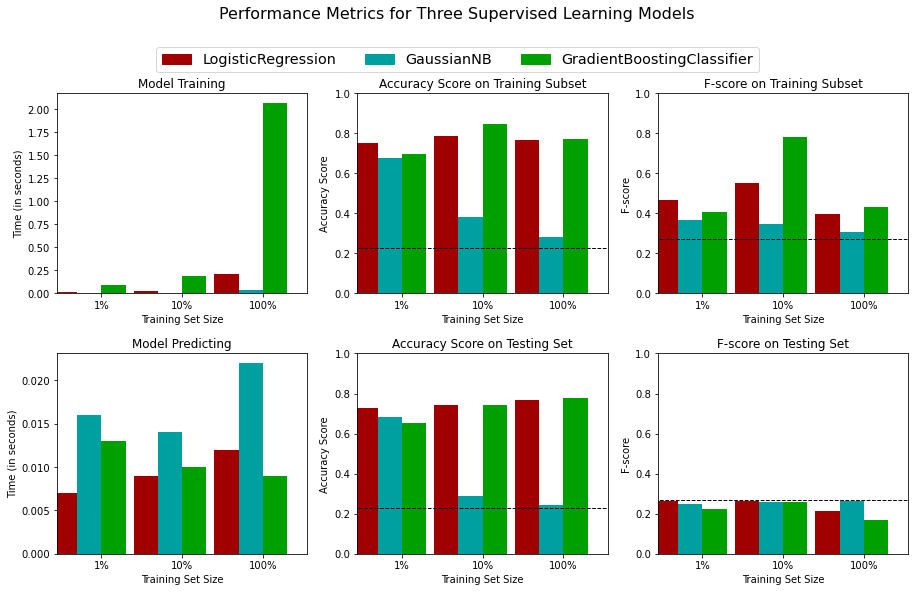

```python
# Initialize the three models
clf_A = LogisticRegression(random_state=42)
clf_B = GaussianNB()
clf_C = GradientBoostingClassifier(random_state=42)

# Calculate the number of samples for 1%, 10%, and 100% of the training data

samples_100 = len(y_train)
samples_10 = int((len(y_train)) * 0.1)
samples_1 = int((len(y_train)) * 0.01)

# Collect results on the learners
results = {}
for clf in [clf_A, clf_B, clf_C]:
    clf_name = clf.__class__.__name__
    results[clf_name] = {}
    for i, samples in enumerate([samples_1, samples_10, samples_100]):
        results[clf_name][i] = \
        train_predict(clf, samples, X_train, y_train, X_test, y_test)

# Run metrics visualization for the three supervised learning models chosen
vs.evaluate(results, accuracy, fscore)
```

```python
# Initialize the classifier
clf = GradientBoostingClassifier(random_state=42)

# Create the parameters list you wish to tune, using a dictionary if needed.
# parameters = {'parameter_1': [value1, value2], 'parameter_2': [value1, value2]}
parameters = {'min_samples_split':[2, 5, 10], 'min_samples_leaf':[1, 2, 5, 10]}

# Make an fbeta_score scoring object using make_scorer()
scorer = make_scorer(fbeta_score, beta=0.5)

# Perform grid search on the classifier using 'scorer' as the scoring method using GridSearchCV()
grid_obj = GridSearchCV(estimator=clf, param_grid=parameters, scoring=scorer)

# Fit the grid search object to the training data and find the optimal parameters using fit()
grid_fit = grid_obj.fit(X_train, y_train)

# Get the estimator
best_clf = grid_fit.best_estimator_

# Make predictions using the unoptimized and model
predictions = (clf.fit(X_train, y_train)).predict(X_test)
best_predictions = best_clf.predict(X_test)

# Report the before-and-afterscores
print("Unoptimized model\n------")
print("Accuracy score on testing data: {:.4f}".format(accuracy_score(y_test, predictions)))
print("F-score on testing data: {:.4f}".format(fbeta_score(y_test, predictions, beta = 0.5)))
print("\nOptimized Model\n------")
print("Final accuracy score on the testing data: {:.4f}".format(accuracy_score(y_test, best_predictions)))
print("Final F-score on the testing data: {:.4f}".format(fbeta_score(y_test, best_predictions, beta = 0.5)))
```

```
Unoptimized model
------
Accuracy score on testing data: 0.7771
F-score on testing data: 0.1688

Optimized Model
------
Final accuracy score on the testing data: 0.7747
Final F-score on the testing data: 0.1340
```

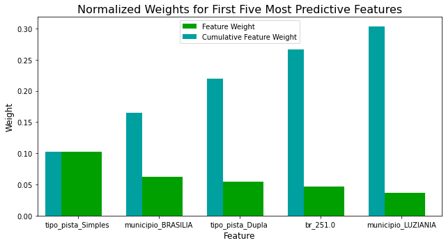

```python
# Import a supervised learning model that has 'feature_importances_'

# Train the supervised model on the training set using .fit(X_train, y_train)
model = GradientBoostingClassifier().fit(X_train, y_train)

# Extract the feature importances using .feature_importances_ a
importances = model.feature_importances_

# Plot
vs.feature_plot(importances, X_train, y_train)
```